# Titanic Kaggle challenge (EDA)

The Titanic challenge is a classic introductory machine learning challenge in the Data Science universe.

The competition is simple: use machine learning to create a model that predicts which passengers survived the Titanic shipwreck. The sinking of the Titanic is one of the most infamous shipwrecks in history.

On April 15, 1912, during her maiden voyage, the widely considered “unsinkable” RMS Titanic sank after colliding with an iceberg. Unfortunately, there weren’t enough lifeboats for everyone on board, resulting in the death of 1502 out of 2224 passengers and crew. While there was some element of luck involved in surviving, it seems some groups of people were more likely to survive than others.

I have divided the problem into exploratory data analysis (EDA), and machine learning model development. This notebook addresses the EDA.

After importing the necessary packages we load the data can be loaded.

```python
import pandas as pd
import numpy as np
import seaborn as sns
from matplotlib import pyplot as plt
from IPython.display import display
sns.set(style="ticks")
```

```python
train = pd.read_csv('../01 data/train.csv')
test = pd.read_csv('../01 data/test.csv')
gender_submission = pd.read_csv('../01 data/gender_submission.csv')
```

All Kaggle's competitions give a training set and a test set. In a "real world" problem the data modeller needs to decide how to split the data between train and test.

Kaggle provides a brief data description that is here reproduce:

| Variable | Definition | Key |
| --- | --- | --- |
| survival | Survival | 0 = No, 1 = Yes |
| pclass | Ticket class | 1 = 1st, 2 = 2nd, 3 = 3rd |
| sex | Sex |  |
| Age | Age in years |  |
| sibsp | # of siblings / spouses aboard the Titanic |  |
| parch | # of parents / children aboard the Titanic |  |
| ticket | Ticket number |  |
| fare | Passenger fare |  |
| cabin | Cabin number |  |
| embarked | Port of Embarkation | C = Cherbourg, Q = Queenstown, S = Southampton |

### Variable Notes

pclass: A proxy for socio-economic status (SES) 1st = Upper 2nd = Middle 3rd = Lower

age: Age is fractional if less than 1. If the age is estimated, is it in the form of xx.5

sibsp: The dataset defines family relations in this way... Sibling = brother, sister, stepbrother, stepsister Spouse = husband, wife (mistresses and fiancés were ignored)

parch: The dataset defines family relations in this way... Parent = mother, father Child = daughter, son, stepdaughter, stepson Some children travelled only with a nanny, therefore parch=0 for them.

Let's take a look at the train dataset. Some key points to look at are:

- what columns does it contain?
- what data type are they?
- what do they represent?
- How many missing values do we have and where?
- Generally, what does the data look like?

As can be seen in the cell below, the DataFrame contains 12 columns 2 of them float, 5 for them integers and 5 strings (objects). It can be seen that Age, Cabin and Embarked are missing some data.

```python
train.info()
```

```
<class 'pandas.core.frame.DataFrame'>
RangeIndex: 891 entries, 0 to 890
Data columns (total 12 columns):
 #   Column       Non-Null Count  Dtype
---  ------       --------------  -----
 0   PassengerId  891 non-null    int64
 1   Survived     891 non-null    int64
 2   Pclass       891 non-null    int64
 3   Name         891 non-null    object
 4   Sex          891 non-null    object
 5   Age          714 non-null    float64
 6   SibSp        891 non-null    int64
 7   Parch        891 non-null    int64
 8   Ticket       891 non-null    object
 9   Fare         891 non-null    float64
 10  Cabin        204 non-null    object
 11  Embarked     889 non-null    object
dtypes: float64(2), int64(5), object(5)
memory usage: 83.7+ KB
```

The number of instances missing per data column is:

```python
display(train.isna().sum())
```

```
PassengerId      0
Survived         0
Pclass           0
Name             0
Sex              0
Age            177
SibSp            0
Parch            0
Ticket           0
Fare             0
Cabin          687
Embarked         2
dtype: int64
```

The percentage of instances missing per data column is:

```python
display(train.isna().sum() / len(train) * 100)
```

```
PassengerId    0.0%
Survived       0.0%
Pclass         0.0%
Name           0.0%
Sex            0.0%
Age           19.9%
SibSp          0.0%
Parch          0.0%
Ticket         0.0%
Fare           0.0%
Cabin         77.1%
Embarked       0.2%
dtype: float64
```

The first five rows of the DataFrame are:

```python
display(train.head())
```

|  | PassengerId | Survived | Pclass | Name | Sex | Age | SibSp | Parch | Ticket | Fare | Cabin | Embarked |
| --- | --- | --- | --- | --- | --- | --- | --- | --- | --- | --- | --- | --- |
| 0 | 1 | 0 | 3 | Braund, Mr. Owen Harris | male | 22.0% | 1 | 0 | A/5 21171 | 7.2% | NaN | S |
| 1 | 2 | 1 | 1 | Cumings, Mrs. John Bradley (Florence Briggs Th... | female | 38.0% | 1 | 0 | PC 17599 | 71.3% | C85 | C |
| 2 | 3 | 1 | 3 | Heikkinen, Miss. Laina | female | 26.0% | 0 | 0 | STON/O2. 3101282 | 7.9% | NaN | S |
| 3 | 4 | 1 | 1 | Futrelle, Mrs. Jacques Heath (Lily May Peel) | female | 35.0% | 1 | 0 | 113803 | 53.1% | C123 | S |
| 4 | 5 | 0 | 3 | Allen, Mr. William Henry | male | 35.0% | 0 | 0 | 373450 | 8.1% | NaN | S |

The last five rows of the DataFrame are:

```python
display(train.tail())
```

|  | PassengerId | Survived | Pclass | Name | Sex | Age | SibSp | Parch | Ticket | Fare | Cabin | Embarked |
| --- | --- | --- | --- | --- | --- | --- | --- | --- | --- | --- | --- | --- |
| 886 | 887 | 0 | 2 | Montvila, Rev. Juozas | male | 27.0% | 0 | 0 | 211536 | 13.0% | NaN | S |
| 887 | 888 | 1 | 1 | Graham, Miss. Margaret Edith | female | 19.0% | 0 | 0 | 112053 | 30.0% | B42 | S |
| 888 | 889 | 0 | 3 | Johnston, Miss. Catherine Helen "Carrie" | female | nan% | 1 | 2 | W./C. 6607 | 23.4% | NaN | S |
| 889 | 890 | 1 | 1 | Behr, Mr. Karl Howell | male | 26.0% | 0 | 0 | 111369 | 30.0% | C148 | C |
| 890 | 891 | 0 | 3 | Dooley, Mr. Patrick | male | 32.0% | 0 | 0 | 370376 | 7.8% | NaN | Q |

The number of missing values is quite substantial in the case of Cabin. In the case of Age, it can potentially be a problem that we'll try to remedy by imputing. the number of missing values in Embarked is negligible.

PassengerId is a mere repetition of the index starting from 1 instead of 0, therefore completely is irrelevant.

The Ticket seems to have some kind of encoding they used at the time, presumably it reflects the location of the purchase, but it's quite cryptic for us now.

The number of unique values per column can through some light on how informative for a predictive model none numeric fields will be. Generally, the fact that the number of unique values is much lower than the total number of records is a good sign, because it allows for instances to be grouped or clustered by these shared identifiers. Hopefully, most of these characteristics will be correlated with the variable we are trying to predict.

```python
train.nunique()
```

```
PassengerId    891
Survived         2
Pclass           3
Name           891
Sex              2
Age             88
SibSp            7
Parch            7
Ticket         681
Fare           248
Cabin          147
Embarked         3
dtype: int64
```

Let's look at total numbers and odds for the different characteristics of the people on board: How many people survived/deceased?

```python
display(pd.DataFrame(train.Survived.value_counts()).set_index(pd.Index(['Deceased', 'Survived'])))
```

|  | Survived |
| --- | --- |
| Deceased | 549 |
| Survived | 342 |

What percentage of people survived/deceased?

```python
pd.options.display.float_format = '{:,.1f}%'.format
display(pd.DataFrame(train.Survived.value_counts(normalize=True) * 100).set_index(pd.Index(['Deceased', 'Survived'])))
```

|  | Survived |
| --- | --- |
| Deceased | 61.6% |
| Survived | 38.4% |

What was the count males/females that survived/deceased?

```python
display(pd.crosstab(train.Survived, train.Sex).set_index(pd.Index(['Deceased', 'Survived'])))
```

| Sex | female | male |
| --- | --- | --- |
| Deceased | 81 | 468 |
| Survived | 233 | 109 |

What was the relative percentage share of males/females that survived/deceased?

```python
pd.options.display.float_format = '{:,.1f}%'.format
display((pd.crosstab(train.Survived, train.Sex, normalize='columns') * 100).set_index(pd.Index(['Deceased', 'Survived'])))
```

| Sex | female | male |
| --- | --- | --- |
| Deceased | 25.8% | 81.1% |
| Survived | 74.2% | 18.9% |

What is the number of survived/deceased by age range with child [0, 18), Adult [18, 65), elderly[65,)?

```python
def Age_ranges(x):
    if x < 18:
        return 'Child'
    elif x < 65:
        return 'Adult'
    elif x >= 65:
        return 'Elderly'


train['Age_ranges'] = train['Age'].apply(Age_ranges)
display(pd.crosstab(train.Survived, train.Age_ranges).set_index(pd.Index(['Deceased', 'Survived'])))
```

| Age_ranges | Adult | Child | Elderly |
| --- | --- | --- | --- |
| Deceased | 362 | 52 | 10 |
| Survived | 228 | 61 | 1 |

What is the survived/deceased relative percentage share by age range with child being [0, 18), Adult [18, 65), and elderly[65,)?

```python
pd.options.display.float_format = '{:,.1f}%'.format
display((pd.crosstab(train.Survived, train.Age_ranges, normalize='columns') * 100).set_index(pd.Index(['Deceased', 'Survived'])))
```

| Age_ranges | Adult | Child | Elderly |
| --- | --- | --- | --- |
| Deceased | 61.4% | 46.0% | 90.9% |
| Survived | 38.6% | 54.0% | 9.1% |

What is the survived/deceased count by passenger class?

```python
display(pd.crosstab(train.Survived, train.Pclass).set_index(pd.Index(['Deceased', 'Survived'])))
```

| Pclass | 1 | 2 | 3 |
| --- | --- | --- | --- |
| Deceased | 80 | 97 | 372 |
| Survived | 136 | 87 | 119 |

From the summaries above we can derive that, overall, 61.6% of the people died, 74.2% of females survived as opposed to 18.8% of males. 54.0% of children, 38.6% of adults and 9.1% of elderly survived. The survival percentage increased with the passenger class with 63.0% for first-class, 47.3% for second and 24.2% for third class.

If we group the deceased/survived by Pclass, Sex and Age range, and calculate the percentage share of deceased/survived, we'll be able to start seeing the patterns that shape the survived/deceased classification.

| Pclass | Sex | Survived Age_ranges | 0 | 1 |
| --- | --- | --- | --- | --- |
| 1 | male | Child | 0.0% | 100.0% |
| 2 | female | Child | 0.0% | 100.0% |
| 1 | female | Adult | 2.6% | 97.4% |
| 2 | female | Adult | 9.7% | 90.3% |
| 1 | female | Child | 12.5% | 87.5% |
| 2 | male | Child | 18.2% | 81.8% |
| 3 | female | Child | 45.7% | 54.3% |
|  |  | Adult | 58.2% | 41.8% |
| 1 | male | Adult | 61.5% | 38.5% |
| 3 | male | Child | 76.7% | 23.3% |
| 1 | male | Elderly | 83.3% | 16.7% |
| 3 | male | Adult | 86.5% | 13.5% |
| 2 | male | Adult | 93.0% | 7.0% |
|  |  | Elderly | 100.0% | 0.0% |
| 3 | male | Elderly | 100.0% | 0.0% |

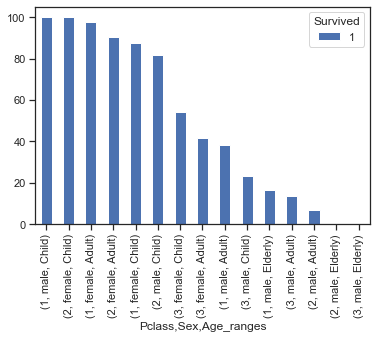

```python
odds = pd.crosstab(train.Survived, [train.Pclass, train.Sex, train.Age_ranges], normalize='columns') * 100
display(odds.T.sort_values(ascending=False, by=[1]))
odds.T.sort_values(ascending=False, by=[1]).plot(y=[1], kind='bar')
```

We can see that Child, Class 1 and two and females tend to have high survival rates while class 3, male and elderly weren't so lucky unfortunately.

The correlation between other variables and Survived can give a good indication of which of the variables will prove more useful when predicting what the fate was of a person onboard the Titanic, based on their characteristics.

```python
train.corr()['Survived']
```

```
PassengerId   -0.0%
Survived       1.0%
Pclass        -0.3%
Age           -0.1%
SibSp         -0.0%
Parch          0.1%
Fare           0.3%
Name: Survived, dtype: float64
```

Although the passengers and crew member's name might not be very informative, the their title does contain information that could be of value. The cell below uses regular expressions to extract the person's title. In the same manner, the cabin's complete reference might not be of much help, but the letter preceding the number might contain correlated with survival chances. The cell below also uses regular expressions to extract the first letter of the Cabin reference.

```python
train['Title'] = train.Name.str.extract(r' ([A-Za-z]+)\.', expand=False)
train['Cabin_letter'] = train.Cabin.str.extract(r' ([a-zA-Z])', expand=False)
```

It would be useful to have plots that showed the survived/deceased split for the values of the different variables. A bar chart is one way to do this.

From the plots created by the cell below we can see that ages around 20 and 40 are more like to have deceased during the tragedy.

Passenger class 3 was by the most numerous class and the class that saw a higher number of deceased. It's somewhat interesting that the number of people that survived of each class is relatively similar.

The relative number of deceased for Mr. was much higher as it is an indicator of a male passenger, while Miss and Mrs had higher numbers or survived compared to deceased.

As mentioned previously, even though the number of males on board was almost more than double the number of females, the number of males survivers was less than have that of females.

Curiously people with one sibling on board were substantially more likely to survive.

People travelling with no family members were sadly more likely to decease.

We must be cautious to draw any conclusions from the cabin data because the sample is very low. But it appears that B cabin passengers were much more likely than C or G passengers to survive.

Passengers embarked at Cherbourg were more likely to survive. Upon further inspection, it was observed that the relative percentage survival of males embarked at Cherbourg (France) was higher than that of their counterparts embarked at Queenstown or Southampton.

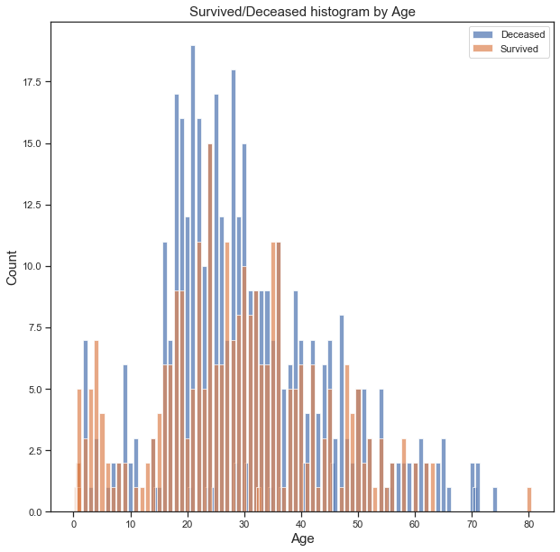

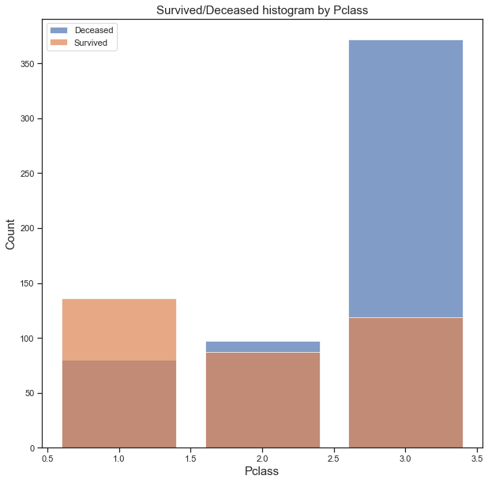

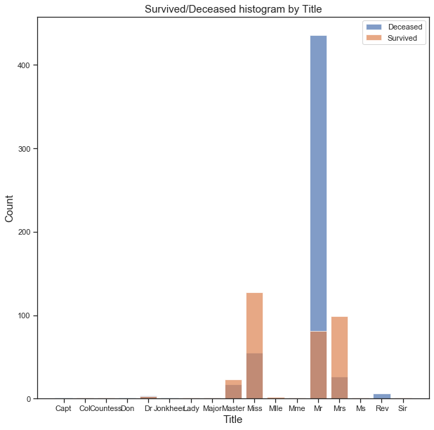

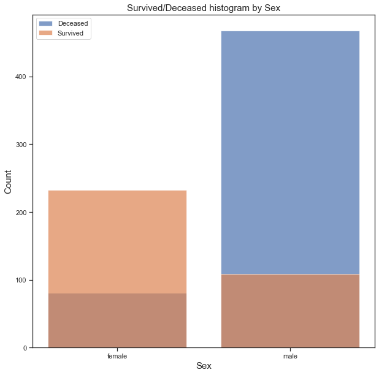

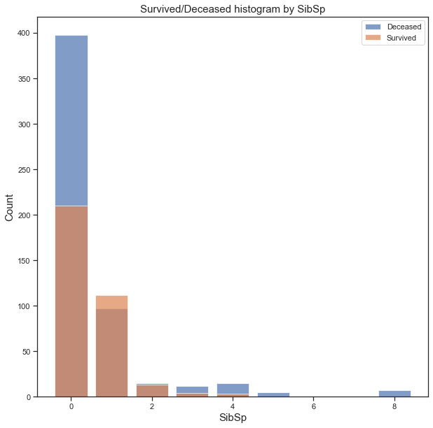

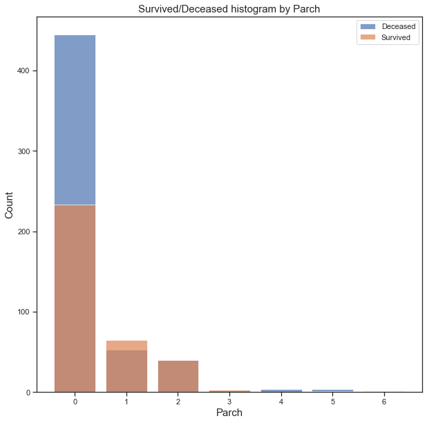

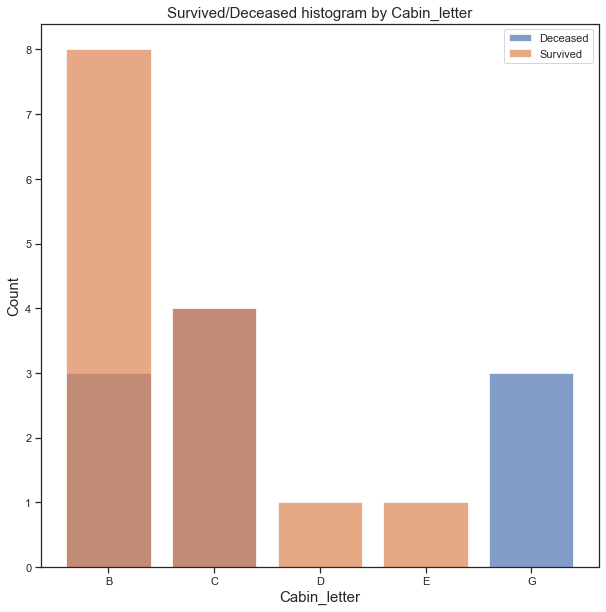

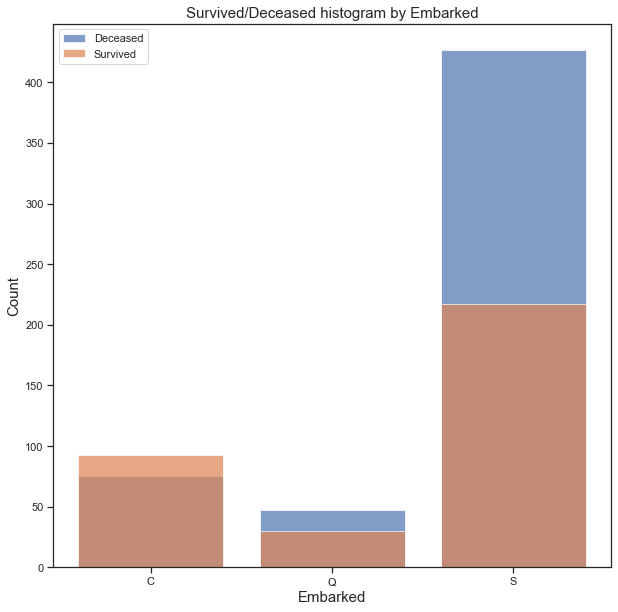

```python
for variable in ['Age', 'Pclass', 'Title', 'Sex', 'SibSp',
                 'Parch', 'Cabin_letter', 'Embarked']:
    fig = plt.figure(figsize=(10, 10))
    grouped = pd.crosstab(train[variable], train.Survived)
    plt.bar(grouped.index, height=grouped[0], label='Deceased', alpha=0.7)
    plt.bar(grouped.index, height=grouped[1], label='Survived', alpha=0.7)
    plt.title(f'Survived/Deceased histogram by {variable}', size=15)
    plt.xlabel(variable, size=15)
    plt.ylabel('Count', size=15)
    plt.legend()
    plt.show()
```

The chart shown below shows how there seems to be a positive correlation between price and relative rate of survival. The higher the price of the ticket the more likely the person holding it was to survive. This is in line with the fact that first-class passengers were more likely to survive.

[figure not shown]

```python
bins = np.histogram_bin_edges(train.Fare, bins=20)
fig = plt.figure(figsize=(10, 10))
plt.hist(train.loc[train.Survived == 0, 'Fare'], bins=bins, label='Deceased', alpha=0.7)
plt.hist(train.loc[train.Survived == 1, 'Fare'], bins=bins, label='Survived', alpha=0.7)
plt.title(f'Survived/Deceased histogram by {variable}', size=15)
plt.xlabel(variable, size=15)
plt.ylabel('Count', size=15)
plt.legend()
plt.show()
```